# GLMs

## Confidence Intervals

- Getting correct confidence intervals for a non-linear transformation require some extra work as well.
- One reliable (if slow) method is the bootstrap.

```r
# the initial model
model <- glm(REPVOTE  ~ HARDSHIP_INDEX + VOTE24_CHOICE ,
             family = binomial,
             data = chep)

# the number of iterations
nboot<-300
# an empty vector to hold results
mfx<-numeric(nboot)
for(i in 1:nboot) {
  # resampling with replacement from the original data
  boot_data<-model$data[sample(nrow(model$data), replace=T),]

  # fitting the model to the bootstrap replicate
  model <- glm(formula(model),
               family = binomial,
               data = boot_data)
  df1 <- model$data |>
    mutate(VOTE24_CHOICE = "(2) Donald Trump")
  # get the data from the model
  df1$preds <- predict(model, newdata = df1, type = 'response')
  df2 <- model$data |> # get the data from the model and change the focal predictor
    mutate(VOTE24_CHOICE = "(1) Kamala Harris")
  df2$preds <- predict(model, newdata = df2, type = 'response')
  # calculate the average differences across all cases
  mfx[i]<-mean(df2$preds - df1$preds, na.rm = T)

}

quantile(mfx, c(0.025, 0.975))
```

## Model fit

How well does our model fit the data?

### Model fit

- In linear regression, we can assess model fit by looking at the distance between the regression line and actual data points.
- There’s not really an analog in logistic regression: we’re predicting probabilities, but we only ever see a single outcome for each case. So how do we say anything about the quality of a model?

### Model fit

The likelihood function:

$$\begin{align}
\prod^n_{i=1} p_i^{y_i} \times (1-p_i)^{1-y_i}\\
y_i = \text{the actual outcome for an observation}\\
p_i = \text{the predicted outcome for an observation}\\
\prod = \text{the product operator (all these values are multiplied together)}
\end{align}$$

### Model fit

$$\begin{align}
\prod^n_{i=1} p_i^{y_i} \times (1-p_i)^{1-y_i}\\
y_i = \text{the actual outcome for an observation}\\
p_i = \text{the predicted outcome for an observation}\\
\prod = \text{the product operator (all these values are multiplied together)}
\end{align}$$

If $y_i = 1$ then this simplifies to $p \times 1$

If $y_i = 0$ then this simplifies to $1-p$

### Model fit

One method for assessing fit is to compare the likelihood under the fitted model to a “null” model with no predictors.

```r
# the null model
model0<-  glm(REPVOTE  ~ 1 ,
             family = binomial,
             data = chep)
# the comparison
model1 <- glm(REPVOTE  ~ HARDSHIP_INDEX + VOTE24_CHOICE ,
             family = binomial,
             data = chep)

logLik(model0)
```

```
'log Lik.' -3341.041 (df=1)
```

```r
logLik(model1)
```

```
'log Lik.' -1990.679 (df=6)
```

### Model fit

There are several rough analogs for R^2 based on this comparison. For example, McFadden’s $R^2$ value:

$$\text{McFadden } R^2 = \frac{\text{Null Model LL} - \text{Full Model LL}}{\text{Null Model LL}}$$

Higher values indicate a greater improvement over the null model:

```r
(logLik(model0)- logLik(model1))/logLik(model0)
```

```
'log Lik.' 0.4041741 (df=1)
```

### Model Fit and Model Comparison

- How do we know whether one model is better than any other?
- We could compare log likelihoods, but a more intuitive method might be to see how they each perform on “new” data

#### Leave one out cross-validation

- Drop observation i and fit the model on the remaining data
- Predict the fitted model on observation i
- Repeat for each row in the data
- Compare the accuracy of each result

```r
# making an empty matrix to store results
predictions<-matrix(nrow=nrow(chep),  # one row for each observation
                    ncol=3 # one column for each model
                    )
for (i in 1:nrow(chep)) {
  # dropping observation i for training data
  train<-chep[-i,]
  # using observation i for testing data
  test<-chep[i,]
  model1 <- glm(REPVOTE  ~ VOTE24_CHOICE ,
                family = binomial,
                data = train)

  model2 <- glm(REPVOTE  ~ HARDSHIP_INDEX ,
                family = binomial,
                data = train)

  model3 <- glm(REPVOTE  ~ HARDSHIP_INDEX + VOTE24_CHOICE ,
                family = binomial,
                data = train)

  # placing the predictions inside the empty matrix
  predictions[i,1]<-predict(model1, newdata=test, type='response')
  predictions[i,2]<-predict(model2, newdata=test, type='response')
  predictions[i,3]<-predict(model3, newdata=test, type='response')



}
# predictions vs. actual for model 1
table("predicted" =factor(predictions[,1]>.5,  labels=c("No", "Yes")),
      "actual" = chep$REPVOTE)

table("predicted" =factor(predictions[,2]>.5,  labels=c("No", "Yes")),
      "actual" = chep$REPVOTE)

table("predicted" =factor(predictions[,3]>.5,  labels=c("No", "Yes")),
      "actual" = chep$REPVOTE)
```

#### BIC and AIC

- BIC stands for Bayesian Information Criteria.
- AIC stands for Akaike Information Criteria.
- Both values are based on the model likelihood, which, for linear models, is based on the sum of squared residuals:

$${\text{BIC} =k \log{(n)}- 2 \log{(L)}}$$

$${\text{AIC} =2k - 2\log{(L)}}$$

Note that both the AIC and BIC include a penalty for `k`, which is the number of model parameters. So both will penalize models with garbage predictors.

#### BIC and AIC

Lower values of both AIC and BIC indicate better model fits, but they’re only meaningful for comparing between models fitted to the same data.

```r
  model1 <- glm(REPVOTE  ~ VOTE24_CHOICE ,
                family = binomial,
                data = chep)

  model2 <- glm(REPVOTE  ~ HARDSHIP_INDEX ,
                family = binomial,
                data = chep)

  model3 <- glm(REPVOTE  ~ HARDSHIP_INDEX + VOTE24_CHOICE ,
                family = binomial,
                data = chep)

BIC(model1, model2, model3)
```

```
# A tibble: 3 × 2
     df   BIC
  <dbl> <dbl>
1     5 4035.
2     2 6661.
3     6 4032.
```

```r
AIC(model1, model2, model3)
```

```
# A tibble: 3 × 2
     df   AIC
  <dbl> <dbl>
1     5 4002.
2     2 6648.
3     6 3993.
```

#### BIC and AIC for model selection

BIC/AIC are sometimes used to select the “best” model from a list of candidates

- (in larger samples) BIC penalizes complexity more than AIC, so it may be preferable if your goal is to find the simplest model out of several plausible options.
- AIC prioritizes predictive power, so it might be preferable if your primary goal is to find the model that will give the most accurate predictions.
- AIC/BIC both tell you about model fit, not necessarily bias.

#### BIC and AIC for model selection

When comparing AIC/BIC values of two models:

- a difference $\leq 2$ suggests little-to-no difference between the models.
- a difference of $\gt 2$ to $\leq 10$ is moderate support for the model with the lower AIC/BIC.
- a difference of $\gt 10$ is strong support for the model with the lower AIC/BIC

## (Some) Diagnostics for GLMs

- Checking residuals
- Checking for multicollinearity
- Checking influential observations

## (Some) Diagnostics for GLMs

These examples will use the packages [performance](https://easystats.github.io/performance/index.html) and [see](https://easystats.github.io/see/)

```r
# install.packages("performance")
# install.packages("see")
library(performance)
library(see)
```

### Checking residuals

- In linear models, we might examine a residuals vs. fitted plot to identify problems like non-linearity, outliers, or unequal variance.
- This visualizes the prediction (fit) for a linear model on the x axis against the residuals on the y-axis.
- However, this isn’t really an option for something like a GLM, because we don’t have “residuals” to measure.

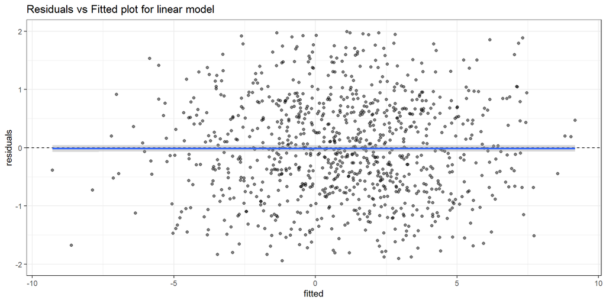

#### Binned Residuals

One option we can use for logit and probit models is a binned residuals plot.

- Calculate the difference between the outcome (y=1 or y=0) and the predicted probability of y=1 for each observation
- Group the data into a smaller number of “bins” based on the predicted probability of y=1.
- Calculate a residual by taking the proportion of y=1 within each bin vs. the average predicted probability of y=1.
- Calculate 95% error bands for each residual based on $2\sqrt{p(1-p)/n}$ where $p$ is the average prediction, and n is the number of observations in each bin.

#### Reading a binned residuals plot

- Ideally, about 95% of the binned residuals should fall within the calculated error bands (the shaded region).
- $>80\%$ of observations falling within the range is considered “acceptable”
- $<80\%$ may indicate a problem with with model.

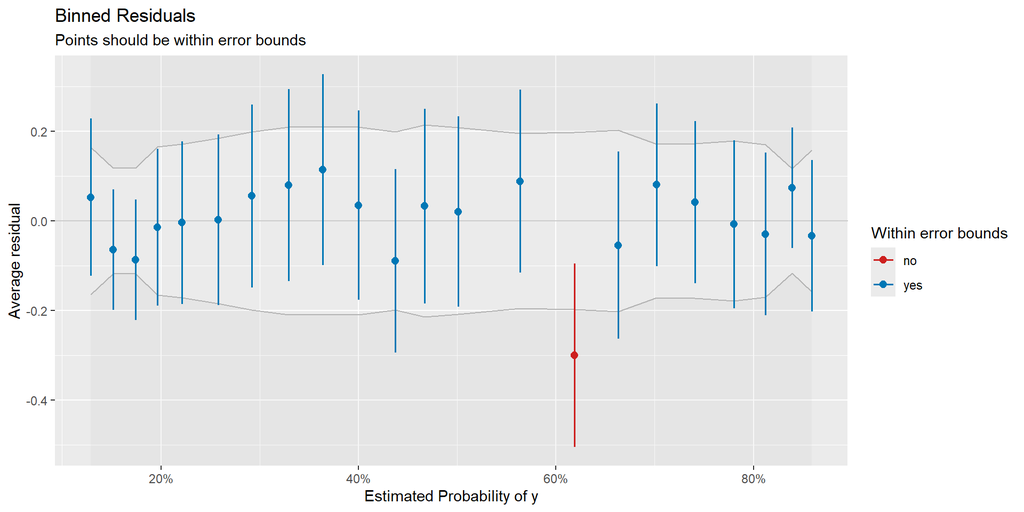

#### Reading a binned residuals plot

- Systematic over/under-prediction in certain regions of the plot could indicate that important predictors are missing or that one of your variables has a non-linear effect on the probability of y=1.
- Excessive predictions outside of the error bounds might just indicate a poor overall fit.

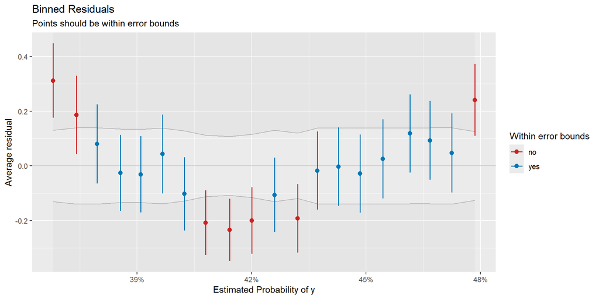

#### Reading a binned residuals plot

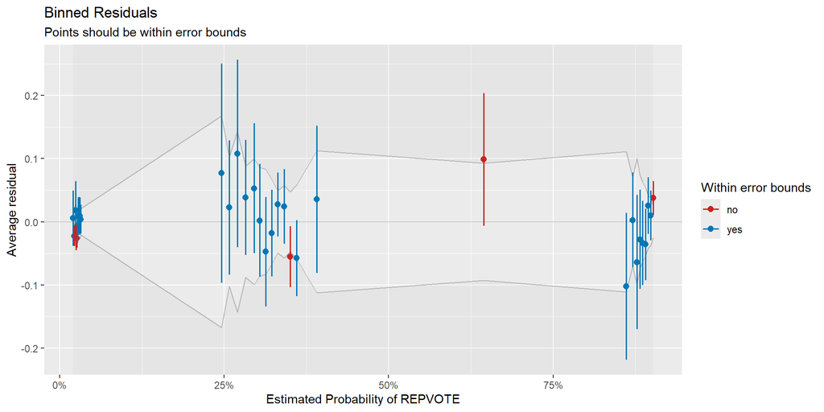

```r
model<-glm(
  REPVOTE  ~ HARDSHIP_INDEX + VOTE24_CHOICE ,
  family = binomial,
  data = chep)

# get the binned residuals
resid<-binned_residuals(model)
# plot the binned residuals
plot(resid)
```

### Checking for multicollinearity

- Multicollinearity refers to a scenario where two or more predictors in a model are correlated with each other.
- We generally expect predictors to be at least partly correlated, but, when predictors are almost perfectly correlated it can have the effect of inflating standard errors on coefficients.

#### Checking for multicollinearity

- The Variance Inflation Factor is one metric that can be used to quantify how much of a multicollinearity problem might exist for a given model.
- The VIF can be interpreted as indicating how much the variance of an estimated coefficient in inflated by its correlation with other variables in the model.

#### Checking for multicollinearity

- High VIF scores (usually >10) might indicate that you’ve included some predictors that are effectively redundant.
- For instance, using gender and sex in the model could potentially cause issues because, for most respondents, these two characteristics tend to align. In this case it probably makes sense to drop one of the variables.

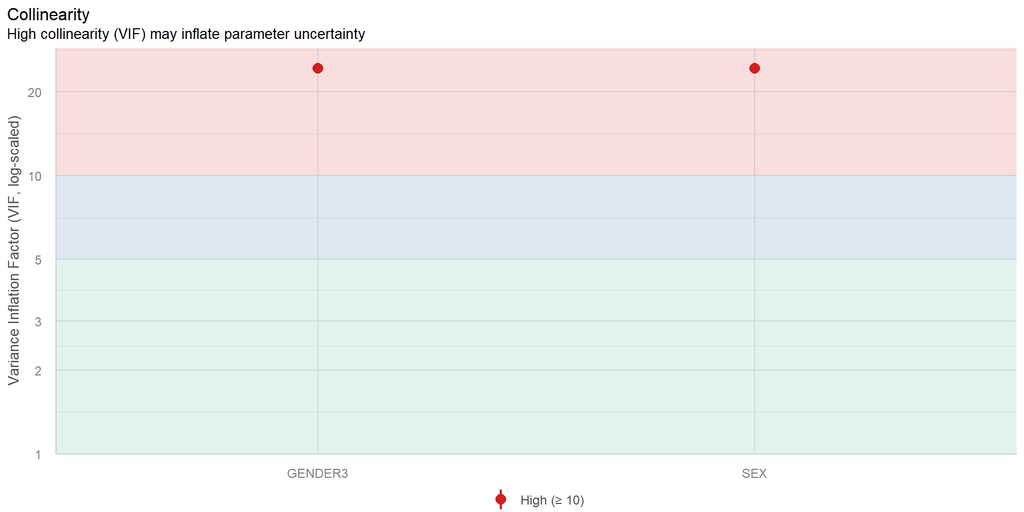

```r
model<-glm(
  REPVOTE  ~ GENDER3 +SEX,
  family = binomial,
  data = chep)



check_collinearity(model)|>
  plot()
```

#### Checking for multicollinearity

- It’s still okay to include predictors that are somewhat correlated with each other. Gender has some association with 2024 vote choice, but it doesn’t give us much reason for concern here.
- High VIF alone isn’t necessarily a good reason to drop a predictor, but it might give you a reason to ask whether including a predictor is worthwhile.

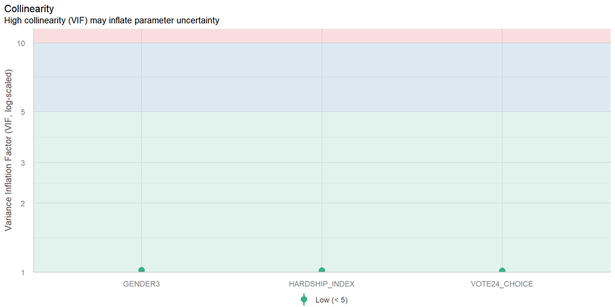

```r
model<-glm(
  REPVOTE  ~ GENDER3  + HARDSHIP_INDEX + VOTE24_CHOICE,
  family = binomial,
  data = chep)



check_collinearity(model)|>
  plot()
```

### Checking for influential observations

- Outliers are observations that have extreme values of the predictors or outcome in a model.
- In regression analysis, we’re particularly concerned about observations have both extreme values of a predictor (leverage) and are poorly predicted by the model (influence)
- Problematic observations are sometimes identified using “Cook’s Distance”, which is essentially a measure of how much dropping a single observation changes the model parameters.

#### Checking outliers

- The x-axis here shows leverage, the y-axis shows the standardized residual from the model.
- The contour lines show an estimate of Cook’s distance at that point. Points outside the contour line may be worth investigating.
- In the present example, we really don’t have much reason for concern.
- In cases where an observation is outside the lines, we *might* consider dropping it, but the best practice would be to try to figure out why it has such extreme values and model it.

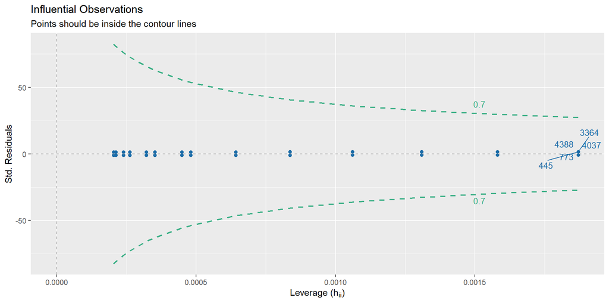

```r
model<-glm(
  REPVOTE  ~ HARDSHIP_INDEX,
  family = binomial,
  data = chep)

check_outliers(model)|>
  plot()
```

## Some Other Generalized Linear Models

- Logistic regression is probably the most well-known example of a generalized linear model, but there’s a whole lot of other types you might come across.
- We’ll briefly look at three others: Ordered Logistic Regression, Tobit, and Zero-Inflated count models.

### Ordered Logistic Regression

An ordered logit extends the logit model to a set of $K$ ordered outcomes (such as a likert response ranging from “Strongly Disagree” to “Strongly Agree”)

Rather than estimating the log-odds of Y=1, an ordered logit model estimates the log-odds of being in a higher category vs. a lower category.

$$\log \left( \frac{P(Y_i\leq k_j)}{1-P(Y_i\leq k_j)} \right)$$

#### Ordered Logistic Regression

- For instance, what if I wanted to make predictions about support/opposition to AI data center construction?
- I *could* collapse these responses into two categories (support vs. non-support) and run a logistic regression, but that might lose a lot of nuance. So a more complicated model might be preferable.
- I could also treat the ordered outcome as if it were continuous, but this makes the (potentially unrealistic) assumption that the categories are “equally spaced”.

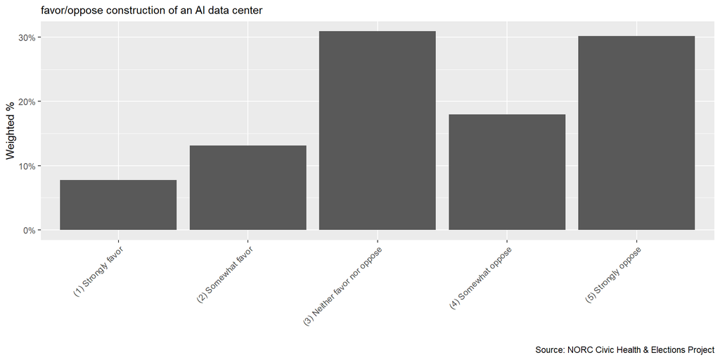

#### Ordered Logistic Regression

One way to interpret an ordered logistic regression is as a latent variable model where a continuous latent outcome $Y^*$ is a linear function of the predictors.

We don’t observe $Y^*$, but we do observe a categorical response based on $Y^*$:

$$\begin{align*}
y= \left\{
\begin{array}{r@{}l}
\text{Strongly Favor} &= \text{if } y* \leq u_1, \\
\text{Somewhat Favor} &= \text{if } u_1 \lt y^* \leq u_2, \\
\text{Neither Favor nor Oppose} &= \text{if } u_2 \lt y^* \leq u_3, \\
\text{Somewhat Oppose} &= \text{if } u_3 \lt y^* \leq u_4, \\
\text{Strongly Oppose} &= \text{if } u_4 \lt y^* \\
\end{array}
\right.
\end{align*}$$

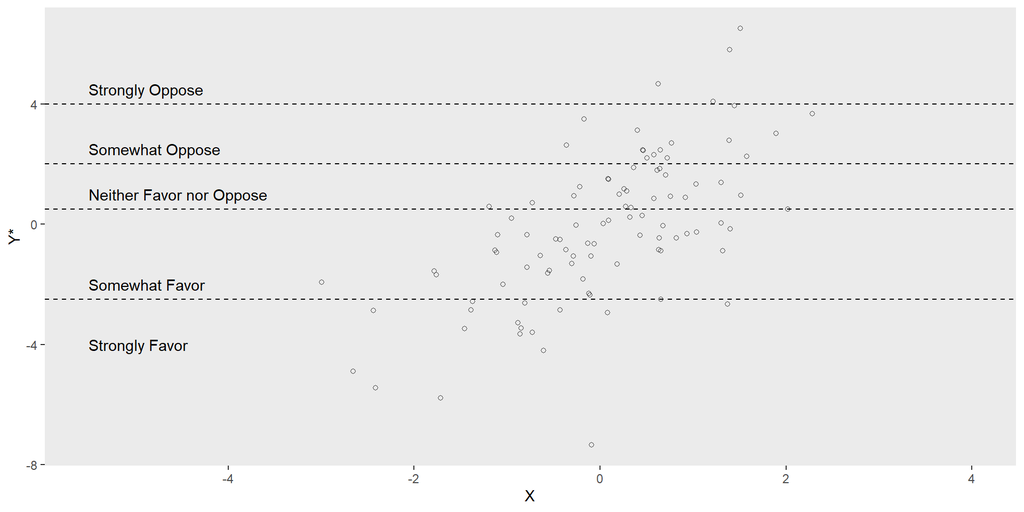

#### Ordered Logistic Regression

- Seen from this perspective, ordered logistic regression estimates both the effect of $X$ on $Y^*$ and the “cut points” that turn it into an ordered category.
- As with logistic regression, these results can also be converted back to the probability scale.

#### Ordered Logistic Regression

```r
# using the MASS package for ordered logit
ologit_model<-MASS::polr(AIFAV_LOCALDATA ~ HARDSHIP_INDEX + SEX + PARTYFULL ,
           data=chep)

summary(ologit_model)
```

```
Call:
MASS::polr(formula = AIFAV_LOCALDATA ~ HARDSHIP_INDEX + SEX +
    PARTYFULL, data = chep)

Coefficients:
                                    Value Std. Error t value
HARDSHIP_INDEX                    0.06959   0.008516   8.172
SEX(2) Female                     0.44726   0.051930   8.613
PARTYFULL(2) Republican/Lean Rep -0.57775   0.055380 -10.433
PARTYFULL(3) Independent         -0.40827   0.081779  -4.992

Intercepts:
                                                 Value    Std. Error t value
(1) Strongly favor|(2) Somewhat favor             -2.4390   0.0714   -34.1644
(2) Somewhat favor|(3) Neither favor nor oppose   -1.2478   0.0584   -21.3813
(3) Neither favor nor oppose|(4) Somewhat oppose   0.0266   0.0551     0.4830
(4) Somewhat oppose|(5) Strongly oppose            0.8445   0.0565    14.9522

Residual Deviance: 14603.91
AIC: 14619.91
```

#### Ordered Logistic Regression

```r
# average marginal effect of going from 0 to 6 on the Hardship Index (all other
# values as observed)
m1<-mutate(ologit_model$model, HARDSHIP_INDEX=0)
preds1<-predict(ologit_model, type='prob', newdata=m1)
m2<-mutate(ologit_model$model, HARDSHIP_INDEX = 6)
preds2<-predict(ologit_model, type='prob', newdata=m2)

colMeans(preds2)-colMeans(preds1)
```

```
          (1) Strongly favor           (2) Somewhat favor
                -0.028214503                 -0.038046136
(3) Neither favor nor oppose          (4) Somewhat oppose
                -0.033992926                  0.009621486
         (5) Strongly oppose
                 0.090632079
```

#### Ordered Logistic Regression

Note that we *could* still use a linear model in this case, and we’ll probably get roughly similar results, but the ordered logit will constrain predictions to the correct response scale.

It also gives us a better model fit overall:

```r
linear_model<-lm(as.numeric(AIFAV_LOCALDATA) ~ HARDSHIP_INDEX + SEX + PARTYFULL, data=chep)
ologit_model<-MASS::polr(AIFAV_LOCALDATA ~ HARDSHIP_INDEX + SEX + PARTYFULL ,
           data=chep)

AIC(linear_model, ologit_model)
```

```
# A tibble: 2 × 2
     df    AIC
  <dbl>  <dbl>
1     6 16388.
2     8 14620.
```

### Tobit

- Tobit models are used in cases where the dependent variable is “censored”, meaning it has an upper or lower limit (or both) causing observations to “pile up” near the boundary.
- For instance: maybe a test is too easy, so lots of people have the maximum score even though some people may have scored far higher than a 100 if given the chance.
- Or maybe an additive scale doesn’t offer enough scale points, so some people may have had higher or lower values if the scale included more questions or each question had additional options.

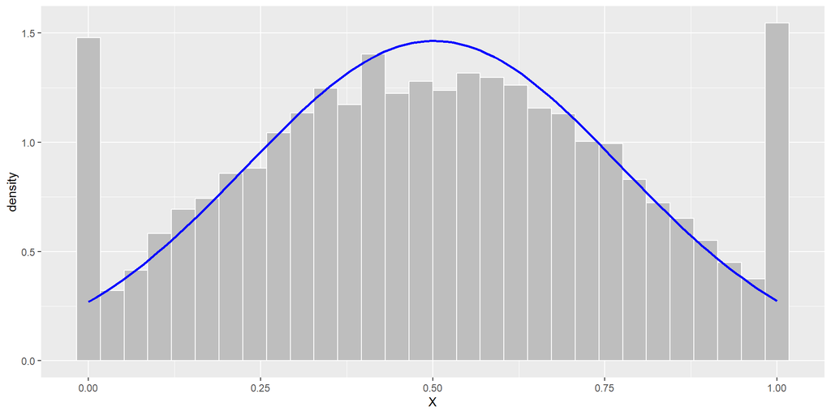

#### Tobit

- We can think of the tobit model as another latent variable model, where there’s a latent $Y^*$ that’s a linear function of the predictors, and an observed $Y$ that’s censored at a minimum or maximum point (or both)
- The tobit model estimates both the effect of $X$ on $Y^*$ and the effect on the probability of censoring.

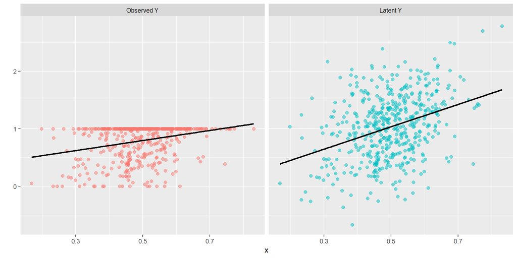

#### Tobit

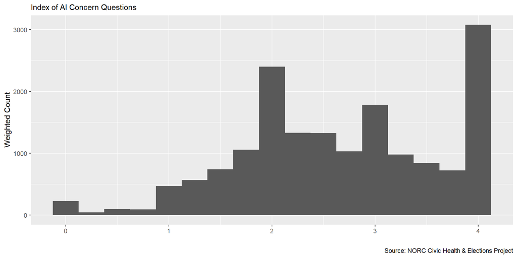

#### Tobit

In a linear model, we see economic hardship has a positive effect on AI Concern:

```r
linear_model<- lm(INDEX_AICONCERN ~ HARDSHIP_INDEX + SEX + EDUC,data=chep)
summary(linear_model)
```

```
Call:
lm(formula = INDEX_AICONCERN ~ HARDSHIP_INDEX + SEX + EDUC, data = chep)

Residuals:
    Min      1Q  Median      3Q     Max
-3.5017 -0.6653  0.0755  0.7794  1.7003

Coefficients:
                                   Estimate Std. Error t value Pr(>|t|)
(Intercept)                        2.299747   0.030999  74.188   <2e-16 ***
HARDSHIP_INDEX                     0.070285   0.004387  16.023   <2e-16 ***
SEX(2) Female                      0.358581   0.027292  13.139   <2e-16 ***
EDUC(2) Some college/assoc. degree 0.055279   0.034222   1.615   0.1063
EDUC(3) College graduate           0.098510   0.037250   2.645   0.0082 **
EDUC(4) Postgraduate study         0.116171   0.042979   2.703   0.0069 **
---
Signif. codes:  0 '***' 0.001 '**' 0.01 '*' 0.05 '.' 0.1 ' ' 1

Residual standard error: 0.9565 on 4994 degrees of freedom
Multiple R-squared:  0.0902,    Adjusted R-squared:  0.08929
F-statistic: 99.03 on 5 and 4994 DF,  p-value: < 2.2e-16
```

#### Tobit

The tobit model produces similar results, but with a slightly stronger coefficient value. However, this coefficient should be interpreted as the effect on the unobserved “latent” value of AI concern.

```r
#install.packages("VGAM")
library(VGAM)
tobit_model<-vglm(
  INDEX_AICONCERN ~ HARDSHIP_INDEX +  SEX + EDUC ,
  family = tobit(Lower = 0, Upper = 4), # censoring at 0 and 4
  data = chep
  )
summary(tobit_model)
```

```
Call:
vglm(formula = INDEX_AICONCERN ~ HARDSHIP_INDEX + SEX + EDUC,
    family = tobit(Lower = 0, Upper = 4), data = chep)

Coefficients:
                                   Estimate Std. Error z value Pr(>|z|)
(Intercept):1                      2.298786   0.039689  57.921   <2e-16 ***
(Intercept):2                      0.177711   0.012321  14.424   <2e-16 ***
HARDSHIP_INDEX                     0.094708   0.005722  16.551   <2e-16 ***
SEX(2) Female                      0.460588   0.034921  13.189   <2e-16 ***
EDUC(2) Some college/assoc. degree 0.064882   0.043784   1.482   0.1384
EDUC(3) College graduate           0.122512   0.047655   2.571   0.0101 *
EDUC(4) Postgraduate study         0.135925   0.054922   2.475   0.0133 *
---
Signif. codes:  0 '***' 0.001 '**' 0.01 '*' 0.05 '.' 0.1 ' ' 1

Names of linear predictors: mu, loglink(sd)

Log-likelihood: -7303.61 on 9993 degrees of freedom

Number of Fisher scoring iterations: 8

No Hauck-Donner effect found in any of the estimates
```

#### Tobit

To get a sense of the effect of HARDSHIP_INDEX on the actual outcome scale, we can calculate a marginal effect on the response scale.

```r
data1<-chep
preds1<-predict(
  tobit_model,
  newdata = data1,
  type = 'response',
  type.fitted = "censored" # this gives us the result with censoring
)
data2<-mutate(chep, HARDSHIP_INDEX = HARDSHIP_INDEX +1)
preds2<-predict(
  tobit_model,
  newdata = data2,
  type = 'response',
  type.fitted = "censored"
)
mean(preds2 - preds1)
```

```
[1] 0.09385498
```

#### Tobit

In this instance the Tobit model has a substantially worse fit than the linear model, which suggests there might not be enough censoring to justify the more complicated model:

```r
AIC(tobit_model)
```

```
[1] 14621.22
```

```r
AIC(linear_model)
```

```
[1] 13752.96
```

### Zero-Inflated Count Models

- In a previous class, we looked at the American Time Use Survey, and noted that many outcomes, like “time spent on childcare” also aren’t really continuously distributed.
- Time use, as measured on the survey, is always a non-negative integer.
- But it also tends to have an inordinate number of zeros: some people will *never* spend time on childcare because they have no children.

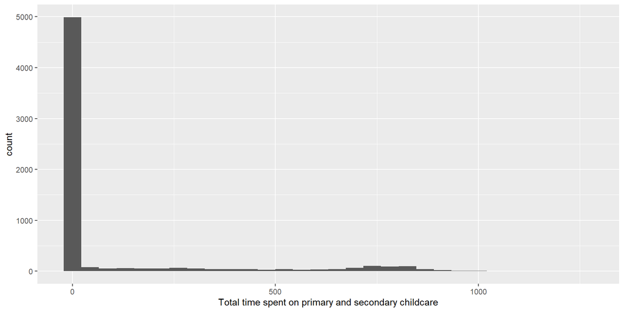

#### Zero-Inflated Count Models

- Zero-Inflated Count models handle this kind of outcome by assuming there are two separate data generating processes:
- A logit model that predicts “structural zeros” (people who don’t have kids)
- A count model that measures the *amount* of time spent on childcare for a person who actually has children. (people who have kids but who may have spent varying amounts of time on childcare when the survey was conducted.)

[figure not shown]

#### Zero-Inflated Count Models

- For instance, this model assumes that age, sex, and number of children will determine whether you spend any time on childcare, but - for those who have children - this will also be influenced by whether or not the survey was completed on a weekend.
- Note that we have two sets of coefficient values. The first predicts the amount of time spent on childcare under the count model, the second predicts the probability of being a “structural zero”.

```r
# install.packages("glmmTMB")
library(glmmTMB)
loc<-'https://github.com/Neilblund/SDSB340-Fall-2026/raw/refs/heads/master/Data/atus25_subset.rds'
atus<-readRDS(url(loc))
atus$weekend<-atus$day%in%c("Saturday", "Sunday")
zip_mod <- glmmTMB(
  childcare_combined ~ age + sex + num_children + weekend, # count model
  ziformula = ~  age + sex + num_children,                 # logit model to predict 0
  family = nbinom2,
  data = atus
)


summary(zip_mod)
```

```
 Family: nbinom2  ( log )
Formula:          childcare_combined ~ age + sex + num_children + weekend
Zero inflation:                      ~age + sex + num_children
Data: atus

     AIC      BIC   logLik deviance df.resid
 19955.9  20023.2  -9968.0  19935.9     6136


Dispersion parameter for nbinom2 family (): 1.49

Conditional model:
              Estimate Std. Error z value Pr(>|z|)
(Intercept)   5.938367   0.125563   47.29  < 2e-16 ***
age          -0.008528   0.002644   -3.23 0.001259 **
sexFemale     0.176152   0.047935    3.67 0.000238 ***
num_children  0.086246   0.025155    3.43 0.000607 ***
weekendTRUE   0.495037   0.047311   10.46  < 2e-16 ***
---
Signif. codes:  0 '***' 0.001 '**' 0.01 '*' 0.05 '.' 0.1 ' ' 1

Zero-inflation model:
             Estimate Std. Error z value Pr(>|z|)
(Intercept)   2.59700    0.19151   13.56  < 2e-16 ***
age           0.01904    0.00329    5.79 7.12e-09 ***
sexFemale    -0.39857    0.10335   -3.86 0.000115 ***
num_children -2.37166    0.07259  -32.67  < 2e-16 ***
---
Signif. codes:  0 '***' 0.001 '**' 0.01 '*' 0.05 '.' 0.1 ' ' 1
```

### GLMS vs. Linear Models

- Notice that in each case we examined here, we had the *option* of using a linear model to fit the data. In some cases the linear model may be preferable for simplicity, ease of interpretation, and robustness.
- When in doubt, you can always try running both and asking “is there a substantial difference in the results here?”. If not, then it’s probably okay to just report one model and put the other in an appendix or mention it in a footnote.